# Lesson on Part of Speech Tagging

## Prerequisites

### Prior Knowledge

This lesson is aimed at students without any prior experience with text analysis of data sets. You will benefit from knowing how to start a terminal on your computer, how to run commands on it and how to do basic coding in the programming language python but we will go over each step required in the lesson for anyone with no previous knowledge of these things.

### Remote Teaching

This lesson was orginally written to teach in a lab with direct feedback to students. We will try our best to teach this remotely now given the current situation. We will take it slow but may get to points where the code might not work on your own laptop in which case it will be difficult to help fixing things for you. But don't worry... the goals is to understand the principals and if you can get things running locally then that's brilliant. If not, we provide all the tagged output files for the collection you will need for further analysis at the end.

### Terminal Setup

**Linux:** Look for Terminal in your applications and click on it to open it.  
**macOS:** Bash is the default shell in all versions of macOS, you do not need to install anything. Open the Terminal application from `/Applications/Utilities` or using Spotlight search.  
**Windows:** Open the Start Menu, type `command` or `cmd` in the search field, and then press Enter or click on the Command Prompt shortcut.

### Software Installs

For this course, we ask you to install Miniconda and as well as the a series of software packages with it (jupyter notebook, nltk, numpy, matplotlib and wordcloud). Please take time to install these different things, ideally before the lesson if you can.

**1. Install Miniconda**

Got to https://docs.conda.io/en/latest/miniconda.html and download the correct version. We will be working with Python version 3.7, so you need to select the appropriate version of Miniconda for your operating system with Python 3.7.

For all of the software packages to be installed next (using conda) you will need to proceed through the terminal installation by pressing "y" when prompted on Linux/Mac or install them via the Anaconda prompt on Windows.

**2. Install Jupyter Notebook**

Windows: install jupyter notebook via the Anaconda prompt  
macOS/Linux: go to a terminal window and run the following command:

```
conda install -c anaconda jupyter
```

**3. Install NLTK**

Windows: install NLTK via the Anaconda prompt  
macOS/Linux: run the following command in your terminal:

```
conda install -c anaconda nltk
```

**4. Install numpy**

Windows: install numpy via the Anaconda prompt  
macOS/Linux: run the following command in your terminal:

```
conda install numpy
```

**5. Install matplotlib**

Windows: install matplotlib via the Anaconda prompt  
macOS/Linux: run the following command in your terminal

```
conda install -c conda-forge matplotlib
```

**6. Install wordcloud**

Windows: install wordcloud via the Anaconda prompt  
macOS/Linux: run the following command in your terminal:

```
conda install -c conda-forge wordcloud
```

## 1. Introduction

Welcome to a hands-on exercise on part-of-speech tagging a dataset. Here we will run through some of the basics that you will need when exploring and analysing text.

To start with here is a bit of basic terminology that will be used in this lesson:

**Token:** is single word, letter, number or punctuation mark

**String:** group of characters comprised of words, letters, numbers, punctuation

**Integer:** positive or negative whole numbers with no decimal point

**Stop word:** generally the most common words in a language (e.g. "the", "of", "and" etc.) which are sometimes filtered out for text analysis purposes in order to focus on the other vocabulary in the text.

**Part of speech (POS) tag:** The POS-tag of a word is a label of the word indicating its part of speech as well as grammatical categories such as tense, number (plural/singular) and case. For exmample, the POS-tag for "sun" is "NN" (noun).

**POS tagging:** POS-tagging is the process of automatically assigning the POS-tags to tokens in a corpus.

**Document:** a single file containing some text

**Corpus:** a collection of documents

## 2. Introduction to Jupyter Notebook

This lesson is run using [Jupyter Notebook](https://jupyter.org). It is an open-source web application that allows you to create and share documents that contain live code, equations, visualizations and narrative text.

### 2.1 Starting Jupyter Notebook server

The start the lesson within a Jupyter Notebook you first need to start a Jupyter Notebook server. To do that you need to open a terminal window and type:

```
jupyter notebook
```

This will open up a browser window containing the base directory of where you can store your notebook on your computer.

You can learn how to open a terminal window on your computer in the Terminal Setup instructions for this lesson.

### 2.2 Creating a new notebook

To create a new notebook you need to select a location for it on your computer via the browser window that opened up and click on "New" in the top right corner of the browser. You also need to select Python 3 to do so.

[figure not shown]

Once the new notebook opens you can give it a name by changing the word "Untitled" in the first line of the new notebook that opens up.

[figure not shown]

You can see the first cell in your new notebook. You can enter python code into this cell and press "Run" as long as it is marked as "Code" in the menu at the top of your notebook. This will run your code and you will see any output created by the code immediately below it.

This should be all you need for using a notebook in this lesson but more information on how to use Jupyter Notebook and how to store a notebook can be found in this Data Carpentries [Overview of Jupyter Notebook](https://datacarpentry.org/python-ecology-lesson/jupyter_notebooks/).

## 3. Introduction to Python

Python is a programming language. We will use this as a way to interact with and analyse text documents. We can use Python either through the command line in your terminal window, by writing Python scripts or via Jupyter Notebook. In this lesson we will be using it via Jupyter Notebook.

This introduction to Python is important for understanding all the steps that follow in the text mining lesson. If you are new to programming it may not be entirely clear why you need to learn Python first. Bare with us, you will soon understand why it is needed and is useful and it will help to speed things up later-on.

We will limit this introduction to the level of Python required for this lesson for a more in-depth introduction to Python, we'd recommend the following [Library Carpentries lesson]{https://librarycarpentry.org/lc-python-intro/}.

### 3.1 Printing text on screen

We first want to test that the Python works by asking it to print a string, so type `print("Hello World")` into the next Jupyter Notebook cell as shown below and run it as code.

```python
print("Hello World")
```

```
Hello World
```

### 3.2 Variables and how to assign them

In python, you can assign information to variables. A variable is a memory location used to hold data which has a name associated with it. You can think of it like a box which can contain information and which also has a name, so you can refer to it in code.

For example we can put the string "text mining" into the box named "text".

We do that by assigning the string to the variable named text. When assigning variables in python, the name of the variable is on the left followed by an equal sign and the value of the variable, as follows:

```python
text = "Text Mining"
```

You can see the content of the variable (what's in the box) by printing the value of it using the `print()` function and the variable name as shown:

```python
print(text)
```

```
Text Mining
```

In addition to strings we can assign other data types such as numbers and floats to variables.

```python
text = "part of speech"  # An example of a string
number = 42  # An example of an integer
pi_value = 3.1415  # An example of a float
print(text)
```

```
part of speech
```

In this lesson we will be concentrating mainly on strings of text.

#### Note

> Whenever something is followed by the `#` sign in Python code (see above examples) then it is a comment and not part of the code. Comments are used to explain the code but are not needed to run it.

### 3.3 A list

Data can be grouped together in an ordered way using a list. Lists are very common data structures used in Python, for example to represent text.

In the following example the list named "sentence" stores all the words and punctuation of the sentence "Just think happy thoughts and you'll smile."

In Python lists are created by typing comma separated values inside square brackets. You can print out all elements in the list.

```python
sentence = ['Just', 'think', 'happy','thoughts', 'and', 'you', '’ll', 'smile', '.', ' [J.B. Barrie]']
print(sentence) # print all elements
```

```
['Just', 'think', 'happy', 'thoughts', 'and', 'you', '’ll', 'smile', '.', ' [J.B. Barrie]']
```

The list holds a sequence of elements (in this case words or punctuation) and each element can be accessed using its index or position in the list. To do that you need to specify the index.

#### Note

> Python indexes start with 0 instead of 1. So the first element in the list is called using a 0 in square brackets after the name of the list

```python
print(sentence[0]) # print the first element
```

```
Just
```

You can also print a slice of the list (e.g. the first two elements of the list):

```python
sentence[0:2]
```

```
['Just', 'think']
```

### 3.4 A for loop

A for loop can be used to access the elements in a list one at a time.

The syntax for a for loop starts with `for x in y:` where y is the thing you want to loop through (in our case a list) and x is a new variable which each element of y is assigned to while looping. So when looping, x keeps getting overwritten by the next element of y until the end of y is reached.

The code after the initial line then specifies what is to be done with each element of y. This needs to be indented using a tab so that Python knows the instructions that follow need to be executed for each element.

For example, you can loop through the sentence list by assigning each element to the word variable and then print each element by calling the `print()` function:

```python
for word in sentence:
    print(word) # prints each element of the list one after the other
```

```
Just
think
happy
thoughts
and
you
’ll
smile
.
 [J.B. Barrie]
```

### 3.5 A tuple

A tuple is similar to a list as it is an ordered sequence of elements. The difference is that tuples can't be changed once created and they are created by placing comma-separated values inside parentheses.

```python
haircolour_tuple = ('hair', 'brown')
eyecolour_tuple = ('eyes', 'blue')
print("Hair colour: "+ haircolour_tuple[1]) # prints the 2nd entry in the tuple
print("Eye colour: " + eyecolour_tuple[1])
```

```
Hair colour: brown
Eye colour: blue
```

## 4. Importing Packages

Python has a selection of pre-written code that can be used. These come as in built functions and a library of packages of modules. We have already used the in-built function `print()`. In-built functions are available as soon as you start python. There is also a (software) library of modules that contain other functions, but these modules need to be imported.

For this course we need to import a few libraries into Python. To do this we need to use the `import` command.

NLTK is the tool which we'll be using to do much of the text processing in this workshop so we need to run `import nltk`.

```python
import nltk
```

## 5. Data Preparation

Text data comes in different forms. You might want to analyse a document in one file or an entire collection of documents (a corpus) stored in multiple files. In this part of the lesson we will show you how to load a single document and how to load the text of an entire corpus into Python for further analysis.

### 5.1 Download some data

Firstly, please download a dataset and make a note of where it is saved on your computer. We need the path to dataset in order to load and read it for further processing.

We will use the [Medical History of British India](https://data.nls.uk/data/digitised-collections/a-medical-history-of-british-india/) collection provided by the [National Library of Scotland](https://www.nls.uk) as an example:

[figure not shown]

> This dataset forms the first half of the Medical History of British India collection, which itself is part of the broader India Papers collection held by the Library. A Medical History of British India consists of official publications varying from short reports to multi-volume histories related to disease, public health and medical research between circa 1850 to 1950. These are historical sources for a period which witnessed the transition from a humoral to a biochemical tradition, which was based on laboratorial science and document the important breakthroughs in bacteriology, parasitology and the developments of vaccines in a colonial context.

This collection has been made available as part of NLS's DataFoundry platform which provides access to a number of their digitised collections.

We are only interested in the text the Medical History of British India collection for this course so at the bottom of the website, download the "Just the text" data or download it directly [here](https://nlsfoundry.s3.amazonaws.com/text/nls-text-indiaPapers.zip).

Note that this dataset requires approx. 120 MB of free file space on your computer once it has been unzipped. Most computers automatically uncompress `.zip` files as the one you have downloaded. If your computer does not do that then right-click on the file and click on uncompress or unzip.

You should be left with a folder called `nls-text-indiaPapers` containing all the `.txt` files for this collection. Please check that you have that on your computer and find out what its file path is. In my case it is `/Users/balex/Downloads/nls-text-indiaPapers/`.

### 5.2 Loading and tokenising a single document

You can use the `open()` function to open one file in the Medical History of British India corpus. You need to specify the path to a file in the downloaded dataset and the mode of opening it ('r' for read). The path will be different to the one below depending on where you saved the data on your computer.

The `read()` function is used to read the file. The file's content (the text) is then stored as a string variable called `mhbi74457530_raw`.

You can then tokenise the text and convert it to lowercase. You can check it has worked by printing out a slice (e.g. the first 20 words) of the list `mhbi74457530_tokens_lc`.

```python
from nltk.tokenize import word_tokenize
nltk.download('punkt')

file = open('/Users/balex/Downloads/nls-text-indiaPapers/74457530.txt','r')  # replace the path with the one on your computer
mhbi74457530_raw = file.read()
mhbi74457530_tokens = word_tokenize(mhbi74457530_raw)
mhbi74457530_tokens_lc = [word.lower() for word in mhbi74457530_tokens]
mhbi74457530_tokens_lc[0:20]
```

```
['no',
 '.',
 '1111',
 '(',
 'sanitary',
 ')',
 ',',
 'dated',
 'ootacamund',
 ',',
 'the',
 '6th',
 'october',
 '1876',
 '.',
 'from-the',
 'honourable',
 'w.',
 'hudleston',
 ',']
```

### 5.3 Loading and tokenising a corpus

We can do the same for an entire collection of documents (a corpus). Here we choose a collection of raw text documents in a given directory. We will use the entire Medical History of British India collection as our dataset. This data set is much larger so processing it will take a lot longer.

#### Note

> When you press run on a bit of code in your notebook, you will know that the processing is finished when the asterix in square brackets to the left of the window will switch to a number.

To read the text files in this collection we can use the `PlaintextCorpusReader` class provided in the `corpus` package of NLTK. You need to specify the collection directory name and a wildcard for which files to read in the directory (e.g. `.*txt` for all .txt files in the directory) and the text encoding of the files (in this case `latin1`). Using the `words()` method provided by NLTK, the text is automatically tokenised and stored in a list of words. We can then lowercase the words in the list. We'll not bother lowercasing this corpus to save some but you can try doing that yourself if you like and there is time.

```python
from nltk.corpus import PlaintextCorpusReader
corpus_root = '/Users/balex/Downloads/nls-text-indiaPapers/'
mhbi_wordlists = PlaintextCorpusReader(corpus_root, '.*txt', encoding='latin1')
mhbi_corpus_tokens = mhbi_wordlists.words()
print(mhbi_corpus_tokens[:20])
```

```
['No', '.', '1111', '(', 'Sanitary', '),', 'dated', 'Ootacamund', ',', 'the', '6th', 'October', '1876', '.', 'From', '-', 'The', 'Honourable', 'W', '.']
```

Now let's move on to tagging text with part-of-speech tags. We'll show you how to do that on one of the files of the collection to save time in class but at the end we'll show you how to do it for the entire corpus.

## 6. Part-of-speech tagging text

For text and corpus analyis, it can be useful to extract words that have a particular part of speech (POS) such as a noun or a verb. For example extracting all proper nouns can give use names and locations. This is done using a POS-tagger. The POS-tag of a word is a label of the word indicating its part of speech as well as grammatical categories such as tense, number (plural/singular) and case. POS tagging is the process of automatically determining the POS-tags of the tokens in a corpus.

In this lesson, we will use NLTK’s `averaged_perceptron_tagger` as the POS-tagger. It uses the perceptron algorithm to predict which POS-tag is most likely given the word. We need to download the tagger in order to use it.

The POS-tagger outputs tokens tagged with their POS-tag. It uses the [Penn Treebank POS tagset](https://www.ling.upenn.edu/courses/Fall_2003/ling001/penn_treebank_pos.html) which is widely used for POS-tagging text.

POS-tagging text is very useful when analysing a corpus or document and will allow us to do more indepth analysis and visualisations. In order to pos-tag using NLTK, you also have to import `pos_tag` from the `tag` package.

```python
nltk.download('averaged_perceptron_tagger')
from nltk.tag import pos_tag
```

### 6.1 POS-tagging a file

Let's pos-tag the file `74457530.txt` from the Medical History of British India corpus which we have tokenised before. To do that we need to run the `pos_tag()` method specifying the tokenised file in brackets. Let's print out a slice to see what the output looks like.

```python
mhbi74457530_tagged = nltk.pos_tag(mhbi74457530_tokens)
mhbi74457530_tagged[87:109]
```

```
[('I', 'PRP'),
 ('am', 'VBP'),
 ('directed', 'VBN'),
 ('to', 'TO'),
 ('forward', 'VB'),
 ('copies', 'NNS'),
 ('of', 'IN'),
 ('the', 'DT'),
 ('annual', 'JJ'),
 ('re-', 'JJ'),
 ('port', 'NN'),
 ('of', 'IN'),
 ('the', 'DT'),
 ('Sanitary', 'NNP'),
 ('Commis-', 'NNP'),
 ('sioner', 'NN'),
 (',', ','),
 ('Madras', 'NNP'),
 (',', ','),
 ('for', 'IN'),
 ('1875', 'CD'),
 (',', ',')]
```

You can see that each word now appears in a tuple with its POS-tag (e.g. "the" is a DT (determiner), "Madras" is an NNP (singular proper nount) etc.). You can also some some propblems where words are split into different tokens by a hyphen. In such cases, the text could do with some initial data cleaning first before tokenising and tagging it but we won't go into that here.

We can then create a list which holds specific parts of speech such as only all the singual and plural common nouns (NN or NNS). Firstly we set up an empty list and then we search for the nouns, NN singular and NNS plural. We can then print the first 20 nouns in the file. You can see that some of the entries are not real nouns but parts of words caused by hyphenation splitting words in the digitised file.

```python
nouns = []
nouns = [word.lower() for (word, pos) in mhbi74457530_tagged if (pos == 'NN' or pos == 'NNS')]
nouns[:20]
```

```
['ment',
 'resolution',
 'letter',
 'letter',
 'ditto',
 'referring',
 'papers',
 'copies',
 'port',
 'sioner',
 'state',
 'information',
 'regard-',
 'ing',
 'distribution',
 'causation',
 'leprosy',
 'tion',
 'copy',
 'reports']
```

### 6.2 Visualising most frequent nouns in a graph

Now that we have created this list of nouns, we can plot their counts in the corpus. The `plot()` method can be called to draw the frequency distribution as a graph for the most common nouns in the text. "disease", "cases", "lepers" and "leprocy" are frequently mentioned in this collection. You can also visualise lists of other types of part of speech tags by rerunning the previous step with a different Penn Treebank tag.

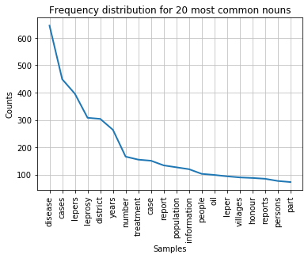

```python
%matplotlib inline
from nltk.probability import FreqDist
fdist = FreqDist(nouns)
fdist.plot(20,title='Frequency distribution for 20 most common nouns')
```

### 6.3 Visualising most fequent nouns in a word cloud

We can also present the nouns as a word cloud. This allows us to see a different representation of the nouns in the collection using the `WordCloud( ).generate_from_frequencies()` method. The input to this method is a frequency dictionary of all tokens and their counts in the text. This needs to be created first by importing the `Counter` package in python and creating a dictionary using the `nouns` list as input. We generate the WordCloud using the frequency dictionary and plot the figure to size. We can show the plot using `plt.show()`.

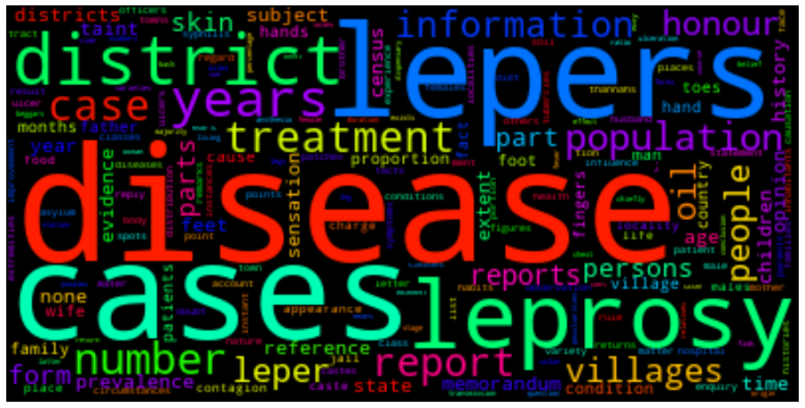

```python
from collections import Counter
dictionary=Counter(nouns)

from wordcloud import WordCloud
%matplotlib inline
import matplotlib.pyplot as plt
cloud = WordCloud(max_font_size=80,colormap="hsv").generate_from_frequencies(dictionary)
plt.rcParams["figure.figsize"] = (16,12)   # this line specifies the size of the graph
plt.imshow(cloud, interpolation='bilinear')  # this line specifies how the words are layed out in the word cloud
plt.axis('off')
plt.show()
```

### 6.4 POS-tagging the entire corpus

Now we will POS-tag the entire collection. The next pieces of code are a bit more advanced for programming beginnners. For the purpose of this class, we won't go into detail explaining each line. However, if you want to try this out yourself then you can copy and paste the code into your notebook and it should run. We also provide the POS-tagged output files for the entire collection on Github, so if you can't run this bit then you have them there for download to use for follow-on analyis.

The first block is to determine all the files in the directory specified, store the file names in a list and print how many files there are using the `len()` (length) method. We are only interested in txt files in the directory.

```python
import os
fileNames =[]
dir = "/Users/balex/Downloads/nls-text-indiaPapers/"

for fileName in os.listdir( dir ):
    if fileName.endswith( ".txt" ):
        fileNames.append(fileName)

print("Size of this corpus:")
print(len(fileNames))
```

```
Size of this corpus:
469
```

This next block takes all the file names in the collection, reads the files one by one, determines sentence boundaries using the `sent_tokenize()` method, tokenises and POS-tags the words in each sentence and then writes this information to a file (one for each original input file).

Before you run this code you need to create an output directory where you want to store the POS-tagged files. I've decided to put mine here `/Users/balex/Downloads/nls-text-indiaPaper-postagged/`. Whatever directory you choose is what you need to add into the `outputdir` path.

Running this bit of code will take a while as the processing is needs to be repeated for all 469 files. Time for a break or a cup of tea. When running this my laptop sounds like it's going to lift off. :-)

Each file that is processed will be printed below (so you know that it was completed) and you should see the output files appear in the output directory specified.

```python
outputdir = "/Users/balex/Downloads/nls-text-indiaPaper-postagged/" #specify the output directory path on your own computer here

for fileName in fileNames:
    fileID=fileName.strip()

    filepath=dir + fileName
    file = open(filepath,'r', encoding='latin1')
    rawText = file.read()
    print("POS tagging file: " + filepath)
    sentences = nltk.sent_tokenize(rawText)
    tokenised = [nltk.word_tokenize(sent) for sent in sentences]
    posTagged = [nltk.pos_tag(sent) for sent in tokenised]
    file.close()

    file_content=""
    for sent in posTagged:
        file_content = file_content + " ".join(word + "_" + tag for word, tag in sent) + "\n"

    fileID = fileName.replace(".txt", "")
    posFileName = fileID + ".pos"
    f = open(outputdir+posFileName, "w")
    f.write(file_content)
    f.close()
```

```
POS tagging file: /Users/balex/Downloads/nls-text-indiaPapers/75034744.txt
POS tagging file: /Users/balex/Downloads/nls-text-indiaPapers/74972252.txt
POS tagging file: /Users/balex/Downloads/nls-text-indiaPapers/74461102.txt
POS tagging file: /Users/balex/Downloads/nls-text-indiaPapers/75225418.txt
POS tagging file: /Users/balex/Downloads/nls-text-indiaPapers/75027472.txt
POS tagging file: /Users/balex/Downloads/nls-text-indiaPapers/75034340.txt
POS tagging file: /Users/balex/Downloads/nls-text-indiaPapers/83156399.txt
POS tagging file: /Users/balex/Downloads/nls-text-indiaPapers/74464867.txt
POS tagging file: /Users/balex/Downloads/nls-text-indiaPapers/76153462.txt
POS tagging file: /Users/balex/Downloads/nls-text-indiaPapers/75025933.txt
POS tagging file: /Users/balex/Downloads/nls-text-indiaPapers/74463660.txt
POS tagging file: /Users/balex/Downloads/nls-text-indiaPapers/82804610.txt
POS tagging file: /Users/balex/Downloads/nls-text-indiaPapers/74464872.txt
POS tagging file: /Users/balex/Downloads/nls-text-indiaPapers/75061618.txt
POS tagging file: /Users/balex/Downloads/nls-text-indiaPapers/74464866.txt
POS tagging file: /Users/balex/Downloads/nls-text-indiaPapers/75231530.txt
POS tagging file: /Users/balex/Downloads/nls-text-indiaPapers/74952418.txt
POS tagging file: /Users/balex/Downloads/nls-text-indiaPapers/91022595.txt
POS tagging file: /Users/balex/Downloads/nls-text-indiaPapers/75198691.txt
POS tagging file: /Users/balex/Downloads/nls-text-indiaPapers/90724055.txt
POS tagging file: /Users/balex/Downloads/nls-text-indiaPapers/90725439.txt
POS tagging file: /Users/balex/Downloads/nls-text-indiaPapers/75027261.txt
POS tagging file: /Users/balex/Downloads/nls-text-indiaPapers/74461103.txt
POS tagging file: /Users/balex/Downloads/nls-text-indiaPapers/75471993.txt
POS tagging file: /Users/balex/Downloads/nls-text-indiaPapers/77008148.txt
POS tagging file: /Users/balex/Downloads/nls-text-indiaPapers/83165626.txt
POS tagging file: /Users/balex/Downloads/nls-text-indiaPapers/75028344.txt
POS tagging file: /Users/balex/Downloads/nls-text-indiaPapers/74972251.txt
POS tagging file: /Users/balex/Downloads/nls-text-indiaPapers/75502957.txt
POS tagging file: /Users/balex/Downloads/nls-text-indiaPapers/75190026.txt
POS tagging file: /Users/balex/Downloads/nls-text-indiaPapers/82803579.txt
POS tagging file: /Users/balex/Downloads/nls-text-indiaPapers/91022597.txt
POS tagging file: /Users/balex/Downloads/nls-text-indiaPapers/74463272.txt
POS tagging file: /Users/balex/Downloads/nls-text-indiaPapers/75061418.txt
POS tagging file: /Users/balex/Downloads/nls-text-indiaPapers/75022290.txt
POS tagging file: /Users/balex/Downloads/nls-text-indiaPapers/75693199.txt
POS tagging file: /Users/balex/Downloads/nls-text-indiaPapers/74464870.txt
POS tagging file: /Users/balex/Downloads/nls-text-indiaPapers/74464864.txt
POS tagging file: /Users/balex/Downloads/nls-text-indiaPapers/75692279.txt
POS tagging file: /Users/balex/Downloads/nls-text-indiaPapers/74908463.txt
```

[output cut: 414 more lines]

```
POS tagging file: /Users/balex/Downloads/nls-text-indiaPapers/74464881.txt
POS tagging file: /Users/balex/Downloads/nls-text-indiaPapers/74996913.txt
POS tagging file: /Users/balex/Downloads/nls-text-indiaPapers/82799497.txt
POS tagging file: /Users/balex/Downloads/nls-text-indiaPapers/75722238.txt
POS tagging file: /Users/balex/Downloads/nls-text-indiaPapers/85747402.txt
POS tagging file: /Users/balex/Downloads/nls-text-indiaPapers/75030881.txt
POS tagging file: /Users/balex/Downloads/nls-text-indiaPapers/87224067.txt
POS tagging file: /Users/balex/Downloads/nls-text-indiaPapers/75676286.txt
POS tagging file: /Users/balex/Downloads/nls-text-indiaPapers/74983067.txt
POS tagging file: /Users/balex/Downloads/nls-text-indiaPapers/91029433.txt
POS tagging file: /Users/balex/Downloads/nls-text-indiaPapers/74918284.txt
POS tagging file: /Users/balex/Downloads/nls-text-indiaPapers/83972064.txt
POS tagging file: /Users/balex/Downloads/nls-text-indiaPapers/75242459.txt
POS tagging file: /Users/balex/Downloads/nls-text-indiaPapers/74465341.txt
POS tagging file: /Users/balex/Downloads/nls-text-indiaPapers/75648803.txt
```